# LSTM Based Sign Language Classifier

#### DataSet

Dataset Description- I have recorded 123 total videos (41 videos each for three words **'hello'** ,**'yes** and **'no'**) of me and my family members doing the signs.

The videos were passed through mediapipe on my local machine which then outputted **21 hand-landmark coordinates** for each hand. These absolute landmarks were saved in the form of text files which are being used here for training.

**Sample output from mediapipe-**

```python
# Replace this line of code to the path of the dataset directory
path = '/home/saksham/GBC/AASD4011-ADV.MATH.DL-I/final-project-in-pairs-team-4011/Dataset'
```

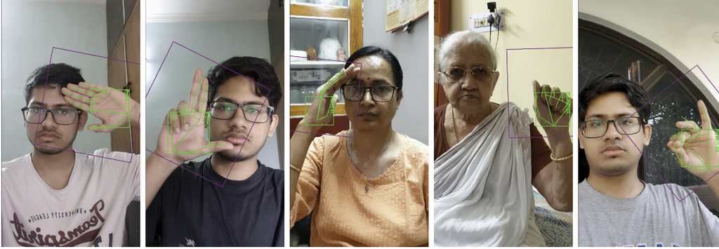

```python
# Example png of the data
Image(f"{path}/example.png", width=550, height=200)
```

# Load Training and Validation Data from text files

```python
# labeling function for the text, reads from the label file
def make_label(text):
    os.chdir(path)
    with open("label.txt", "w") as f:
        f.write(text)
        f.close()
```

```python
#dirname = '/content/drive/My Drive/Dataset/convTrainVal/Absolute/'
dirname = f'{path}/convTrainVal/Absolute/'

# Accessing the Directory
listfile=os.listdir(dirname)

# printing the list of the tags
print (listfile)

# Defining Training and Testing arrays
Xtrain = []
Ytrain = []
Xval = []
Yval = []

# Loop start
for file in listfile:
        # Checking for tags in wordname
        wordname=file
        textlist=os.listdir(dirname+wordname)

        # initial tag = 0
        k=0
        for text in textlist:
            textname=dirname+wordname+"/"+text
            numbers=[]
            with open(textname, mode = 'r') as t:
                numbers = [float(num) for num in t.read().split()]

                for i in range(len(numbers),25200):
                    numbers.extend([0.000])
            row=0
            landmark_frame=[]
            for i in range(0,70):
                landmark_frame.extend(numbers[row:row+84])
                row += 84
            landmark_frame=np.array(landmark_frame)
            landmark_frame=list(landmark_frame.reshape(-1,84))

            if (k%3==2):
                Xval.append(np.array(landmark_frame))
                Yval.append(wordname)
            else:
                Xtrain.append(np.array(landmark_frame))
                Ytrain.append(wordname)
            k+=1
```

```
['yes', 'no', 'hello']
```

```python
# Appending to the array
Xtrain=np.array(Xtrain)
Ytrain=np.array(Ytrain)

Xval=np.array(Xval)
Yval=np.array(Yval)
```

```python
# Shape of the dataset
print("Train Set", Xtrain.shape)
print("Train Labels", Ytrain.shape)
print("Valid Features", Xval.shape)
print("Valid Set", Yval.shape)
```

```
Train Set (66, 70, 84)
Train Labels (66,)
Valid Features (33, 70, 84)
Valid Set (33,)
```

```python
# Shuffling

random.seed(5)

tmp = [[x,y] for x, y in zip(Xtrain, Ytrain)]
random.shuffle(tmp)

tmp1 = [[xt,yt] for xt, yt in zip(Xval, Yval)]
random.shuffle(tmp1)

# Appending in the array
Xtrain = [n[0] for n in tmp]
Ytrain = [n[1] for n in tmp]
Xval = [n[0] for n in tmp1]
Yval = [n[1] for n in tmp1]
```

```python
# Making labels
k=set(Ytrain)
ks=sorted(k)
text=""
for i in ks:
    text=text+i+" "
make_label(text)
```

```python
# Tokenizer
s = Tokenizer()
s.fit_on_texts([text])
print("word_index : ",s.word_index)

encoded=s.texts_to_sequences([Ytrain])[0]
print("sequences : ",encoded,'\n')

encoded1=s.texts_to_sequences([Yval])[0]
print("sequences : ",encoded1,'\n')

# encoding
one_hot = to_categorical(encoded)
one_hot2=to_categorical(encoded1)

(x_train, y_train) = Xtrain, one_hot
(x_val,y_val)=Xval,one_hot2

x_train=np.array(x_train)
y_train=np.array(y_train)
x_val=np.array(x_val)
y_val=np.array(y_val)
```

```
word_index :  {'hello': 1, 'no': 2, 'yes': 3}
sequences :  [1, 3, 2, 1, 2, 1, 2, 2, 3, 3, 2, 1, 3, 3, 3, 2, 1, 3, 2, 2, 1, 3, 3, 2, 1, 2, 3, 1, 2, 3, 1, 1, 1, 1, 1, 1, 2, 2, 3, 3, 1, 1, 3, 3, 2, 3, 3, 1, 2, 3, 2, 2, 1, 2, 2, 3, 3, 1, 2, 3, 1, 2, 1, 3, 1, 2]

sequences :  [3, 3, 1, 1, 2, 2, 2, 3, 1, 1, 2, 2, 3, 2, 1, 2, 2, 1, 3, 3, 3, 1, 1, 1, 3, 3, 1, 2, 3, 1, 2, 2, 3]
```